# Esercizi Algoritmi e Strutture Dati

Gabriele Granzotto

2022-11-13

## **Esercizio 1**

Risolvere il seguente esercizio utilizzando il metodo dell’albero, verificare poi la risposta utilizzando il teorema dell’esperto (se possibile).

$$T(n) = \begin{cases}
2T(\frac{n}{2}) + \Theta(n) & n>1\\
1 & n\leq1
\end{cases}$$

## **Svolgimento**

**Metodo ad albero:**

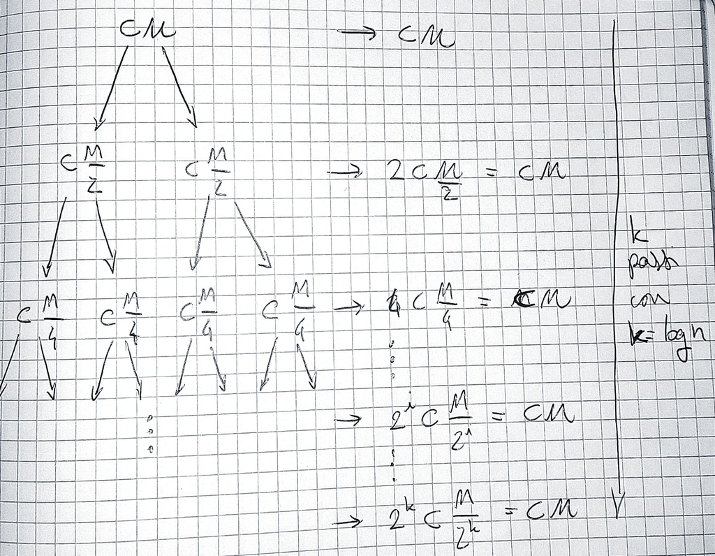

Albero Esercizio 1

$$k = log\ n$$
$$T_M (n) = cn (1+1+1+1+...+1)_{k\ volte} = cnk =
cn\ log\ n$$
$$T(n)=\Theta(n\ log\
n)$$
**Teorema dell’esperto:**

$$a = 2 \qquad b = 2$$
$$f(n)=n\quad sta\ in\quad
\Theta(n^{log_2(2)})=\Theta(n)$$
Quindi:
$$T(n)\in\Theta(n\ log\ n)$$

## **Esercizio 2**

Risolvere il seguente esercizio utilizzando il metodo dell’albero, verificare poi la risposta utilizzando il teorema dell’esperto (se possibile).

$$T(n) = \begin{cases}
2T(\frac{n}{2}) + \Theta(n^2) & n>1\\
1 & n\leq1
\end{cases}$$

## **Svolgimento**

**Metodo ad albero:**

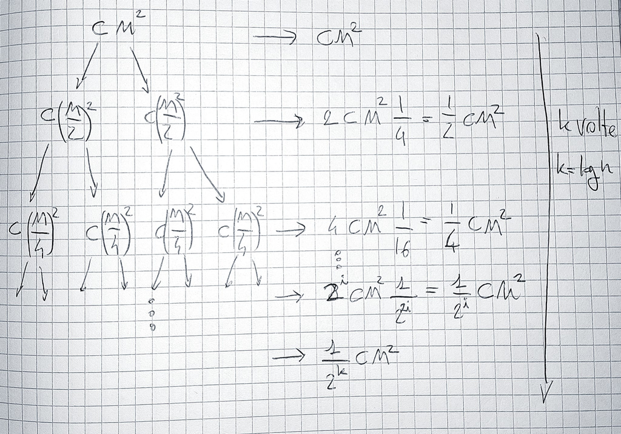

Albero Esercizio 2

$$k = log\ n$$
$$T_M (n) = cn^2
(1+\frac{1}{2}+\frac{1}{4}+...+\frac{1}{2^i}+...+\frac{1}{2^k})_{k\ volte}
= cn^2\ \Sigma_{i=0}^k\frac{1}{2^i} = cn^2(1-\frac{1}{2^k}) =
cn^2(1-\frac{1}{2^{log\ n}}) = cn^2(1-\frac{1}{n})$$
Quindi:

$$T(n)=\Theta(n^2)$$
**Teorema dell’esperto:**

$$a = 2 \qquad b = 2$$
$$f(n)=n^2\quad sta\ in\quad
\Omega(n^{log_2(2)+\epsilon})=\Omega(n^{1+\epsilon})$$

adesso bisogna vedere la seconda condizione:
$$a\cdot f(\frac{n}{b})\leq c\cdot f(n)$$
$$2\cdot f(\frac{n}{2})\leq c\cdot f(n)$$
$$2\cdot (\frac{n}{2})^2\leq
c\cdot n^2$$
$$\frac{n^2}{2}\leq
c\cdot n^2$$
$$1 > c \geq
\frac{1}{2}$$

Quindi:
$$T(n)\in\Theta(n^2)$$

## **Esercizio 3**

Risolvere il seguente esercizio utilizzando il metodo di sostituzione, verificare poi la risposta utilizzando il teorema dell’esperto (se possibile).

$$T(n) = \begin{cases}
4T(\frac{n}{2}) + \Theta(n) & n>1\\
1 & n\leq1
\end{cases}$$

## **Svolgimento**

**Teorema dell’esperto:**

$$a = 4 \qquad b = 2$$
$$f(n)=n\quad sta\ in\quad
O(n^{log_2(4)-\epsilon})=O(n^{2-\epsilon})$$
Quindi:
$$T(n) \in \Theta(n^2)$$

## **Esercizio 4**

Risolvere il seguente esercizio utilizzando il metodo di sostituzione, il metodo ad albero e verificare poi la risposta utilizzando il teorema dell’esperto (se possibile).

$$T(n) = \begin{cases}
2T(\frac{n}{2}) + \Theta(n \ log\ n) & n>1\\
1 & n\leq1
\end{cases}$$

## **Svolgimento**

**Metodo di sostituzione:**

1. Ipotizzo $T(n) \in \Theta(n^2)$
2. Caso base:

provo $n=1$:

$$T(1) = 1$$
quindi:

$$1 \leq 1\cdot c$$

$$1 \leq c$$
quindi:

$$c \geq 1$$

3. Assumo che $\exists c\ \forall m<n: T(m)\leq c \cdot m^2$

$$T(n) \leq 2\frac{cn^2}{2} +n\ log\ n$$
$$2\frac{cn^2}{2} +n\ log\ n \leq
cn^2$$
$$c \geq 2 \frac{log\
n}{n}$$
a $n \rightarrow \infty$ $c\geq0$

quindi:

$$T(n) \in \Theta(n^2)$$

**Metodo dell’albero:**

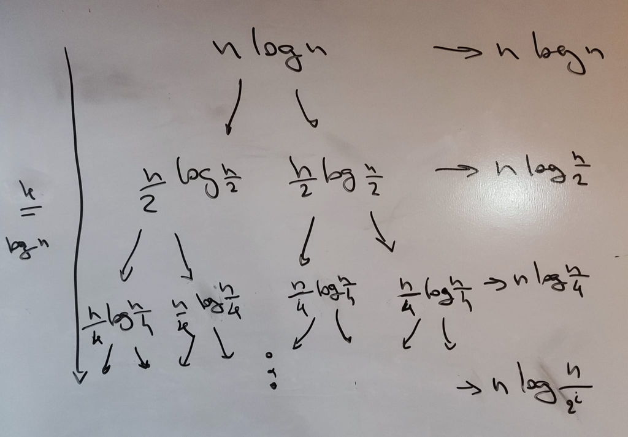

$$n\ log \frac{n}{2^k} \cdot k$$

**Teorema dell’esperto:**

$$a = 2 \qquad b = 2$$
$$f(n)=n\ log\ n \quad sta\ in\quad
\Omega(n^{log_2(2)+\epsilon})=\Omega(n^{1+\epsilon})$$

adesso bisogna vedere la seconda condizione:

$$a\cdot f(\frac{n}{b})\leq c\cdot f(n)$$
$$2\cdot f(\frac{n}{2})\leq c\cdot
f(n)$$
$$2\cdot \frac{n}{2}\
log(\frac{n}{2})\leq c\cdot n\ log\ n$$
$$n\ log(\frac{n}{2})\leq c\cdot n\ log\ n$$
$$log\ n \ -\ 1\leq c\cdot log\ n$$
$$1 > c \geq \frac{log\ n \ -\
1}{log\ n}$$

con $n\rightarrow \infty$ $c=1$, quindi il criterio fallisce.